# Applying Machine Learning to Human Activity Recognition

By Michael O’Flaherty  
September 18th, 2014

#### Background

Human Activity Recognition (**HAR**) has emerged as a key research area by a pervasive research community. Devices such as Jawbone Up, Nike FuelBand, and Fitbit can be used to collect a large amount of personal activity data. People regularly quantify *how much* activity they do, but rarely quantify *how well* they do it. There are many applications for HAR: elderly monitoring, monitoring energy expenditure, weight-loss, and digital assistants for weightlifting. More information about these initiatives is available here: [Human Activity Recognition](http://groupware.les.inf.puc-rio.br/har#ixzz3DQkO6CJM)

This project uses data from accelerometers on the belt, forearm, arm, and dumbell of six participants to develop a prediction model. These participants were asked to perform barbell lifts correctly and incorrectly in five different ways. See the section [Weight Lifting Exercise Dataset](http://groupware.les.inf.puc-rio.br/har) for details on the data set.

#### Data Processing

Data downloaded on **Fri Sep 19 14:53:36 2014**:

```r
if (!file.exists("data")) {
        dir.create("data")
}

trainUrl <- "https://d396qusza40orc.cloudfront.net/predmachlearn/pml-training.csv"
testUrl <- "https://d396qusza40orc.cloudfront.net/predmachlearn/pml-testing.csv"

download.file(trainUrl, "./data/train.csv", method="curl")
download.file(testUrl, "./data/test.csv", method="curl")

train <- read.csv("./data/train.csv", header=TRUE)
test <- read.csv("./data/test.csv", header=TRUE)
```

There are 160 variables in the data sets. The train data set contains 19,622 observations and the test data set contains 20 observations.

#### Preparing the Data Set

Some variables are not necessary and removed. The remaining variables are placed in new data sets called `processedTrain` and `processedTest`:

```r
colsToRemove <- c("X", "user_name", "raw_timestamp_part_1", "new_window",
                  "num_window", "raw_timestamp_part_2", "cvtd_timestamp")
processedTrain <- train[, !names(train) %in% colsToRemove]
processedTest <- test[, !names(test) %in% colsToRemove]
```

```r
naRow <- (rowSums(is.na(train)) == 0)
processedTrain <- processedTrain[!naRow,]
```

```r
stopifnot(require(caret, quietly=TRUE))
nzv <- nearZeroVar(processedTrain)
processedTrain <- processedTrain[,-nzv]
processedTest <- processedTest[,-nzv]
```

After this step, 53 variables remain.

Some predictive models are susceptible to multicollinearity (high correlations between predictors.) Other models, such as classification or regression trees, might be resistant to highly correlated predictors, but multicollinearity may negatively affect interpretability of the model. Either way, we will remove those variables that would weaken our model:

```r
descrCorr <- cor(processedTrain[,sapply(processedTrain, is.numeric)]) # locate all numeric columns and coorelate
highCorr <- findCorrelation(descrCorr, 0.90)
processedTrain <- processedTrain[, -highCorr]
processedTest <- processedTest[, -highCorr]
```

Data cleaning is complete. We have 46 variables remaining with no NA’s in either data set. This was determined by running `str` and `summary` on each data set and reviewing the results. The remaining variables are shown here:

```r
str(processedTrain)
```

```
## 'data.frame':    19216 obs. of  46 variables:
##  $ pitch_belt          : num  8.07 8.07 8.07 8.05 8.07 8.06 8.09 8.13 8.16 8.17 ...
##  $ yaw_belt            : num  -94.4 -94.4 -94.4 -94.4 -94.4 -94.4 -94.4 -94.4 -94.4 -94.4 ...
##  $ total_accel_belt    : int  3 3 3 3 3 3 3 3 3 3 ...
##  $ gyros_belt_x        : num  0 0.02 0 0.02 0.02 0.02 0.02 0.02 0.02 0.03 ...
##  $ gyros_belt_y        : num  0 0 0 0 0.02 0 0 0 0 0 ...
##  $ gyros_belt_z        : num  -0.02 -0.02 -0.02 -0.03 -0.02 -0.02 -0.02 -0.02 -0.02 0 ...
##  $ magnet_belt_x       : int  -3 -7 -2 -6 -6 0 -4 -2 1 -3 ...
##  $ magnet_belt_y       : int  599 608 600 604 600 603 599 603 602 609 ...
##  $ magnet_belt_z       : int  -313 -311 -305 -310 -302 -312 -311 -313 -312 -308 ...
##  $ roll_arm            : num  -128 -128 -128 -128 -128 -128 -128 -128 -128 -128 ...
##  $ pitch_arm           : num  22.5 22.5 22.5 22.1 22.1 22 21.9 21.8 21.7 21.6 ...
##  $ yaw_arm             : num  -161 -161 -161 -161 -161 -161 -161 -161 -161 -161 ...
##  $ total_accel_arm     : int  34 34 34 34 34 34 34 34 34 34 ...
##  $ gyros_arm_x         : num  0 0.02 0.02 0.02 0 0.02 0 0.02 0.02 0.02 ...
```

[output cut: 32 more lines]

#### Model Selection

I chose the `Random Forest` model to predict the exercises performed. Random Forests are not as sensitive to outliers and overfitting.

#### Cross-Validation

To test the accuracy of the proposed model, we create an independent test data set to perform cross-validation using a 60/40 split:

```r
subset <- createDataPartition(y=processedTrain$classe, p=0.6, list=FALSE)
processedTrain.trainSet <- processedTrain[subset, ]
processedTrain.validationSet <- processedTrain[-subset, ]
```

Using the `Caret` package, we fit our model, make our prediction, and use a confusion matrix to check the results:

```r
set.seed(777)
fitRF <- train(classe~., method='rf', data=processedTrain.trainSet, trControl=trainControl(method="cv"))
predVS <- predict(fitRF, processedTrain.validationSet)
confusionMatrix(table(predVS, processedTrain.validationSet$classe))
```

```
## Confusion Matrix and Statistics
##
##
## predVS    A    B    C    D    E
##      A 2185    9    0    0    0
##      B    2 1470   10    1    0
##      C    0    8 1325   16    3
##      D    0    0    5 1238    2
##      E    1    0    0    3 1406
##
## Overall Statistics
##
##                Accuracy : 0.992
##                  95% CI : (0.99, 0.994)
##     No Information Rate : 0.285
##     P-Value [Acc > NIR] : <2e-16
##
##                   Kappa : 0.99
##  Mcnemar's Test P-Value : NA
##
## Statistics by Class:
##
##                      Class: A Class: B Class: C Class: D Class: E
## Sensitivity             0.999    0.989    0.989    0.984    0.996
## Specificity             0.998    0.998    0.996    0.999    0.999
## Pos Pred Value          0.996    0.991    0.980    0.994    0.997
## Neg Pred Value          0.999    0.997    0.998    0.997    0.999
## Prevalence              0.285    0.194    0.174    0.164    0.184
## Detection Rate          0.284    0.191    0.172    0.161    0.183
## Detection Prevalence    0.286    0.193    0.176    0.162    0.183
## Balanced Accuracy       0.998    0.993    0.992    0.992    0.998
```

```r
fitRF
```

```
## Random Forest
##
## 11532 samples
##    45 predictor
##     5 classes: 'A', 'B', 'C', 'D', 'E'
##
## No pre-processing
## Resampling: Cross-Validated (10 fold)
##
## Summary of sample sizes: 10379, 10379, 10378, 10380, 10377, 10379, ...
##
## Resampling results across tuning parameters:
##
##   mtry  Accuracy  Kappa  Accuracy SD  Kappa SD
##    2    1         1      0.002        0.003
##   23    1         1      0.003        0.003
##   45    1         1      0.003        0.003
##
## Accuracy was used to select the optimal model using  the largest value.
## The final value used for the model was mtry = 23.
```

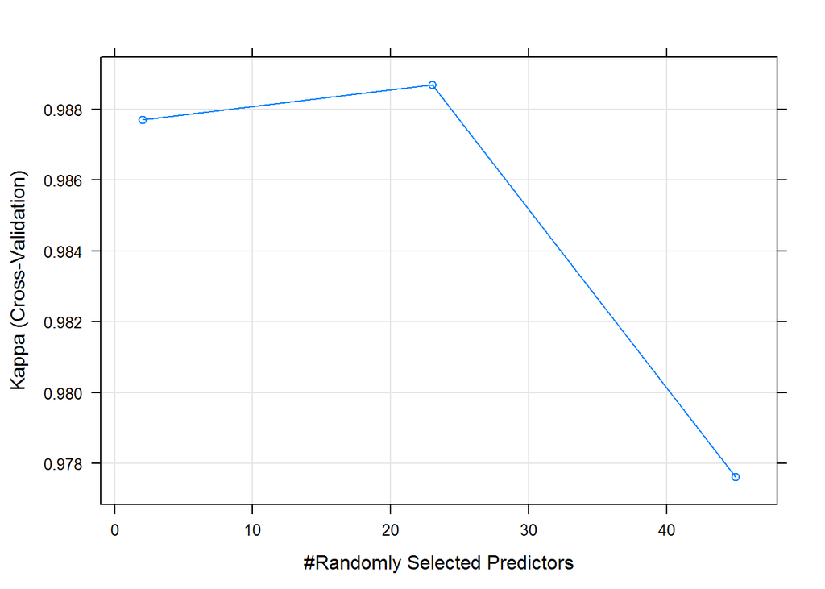

```r
plot(fitRF, metric="Kappa")
```

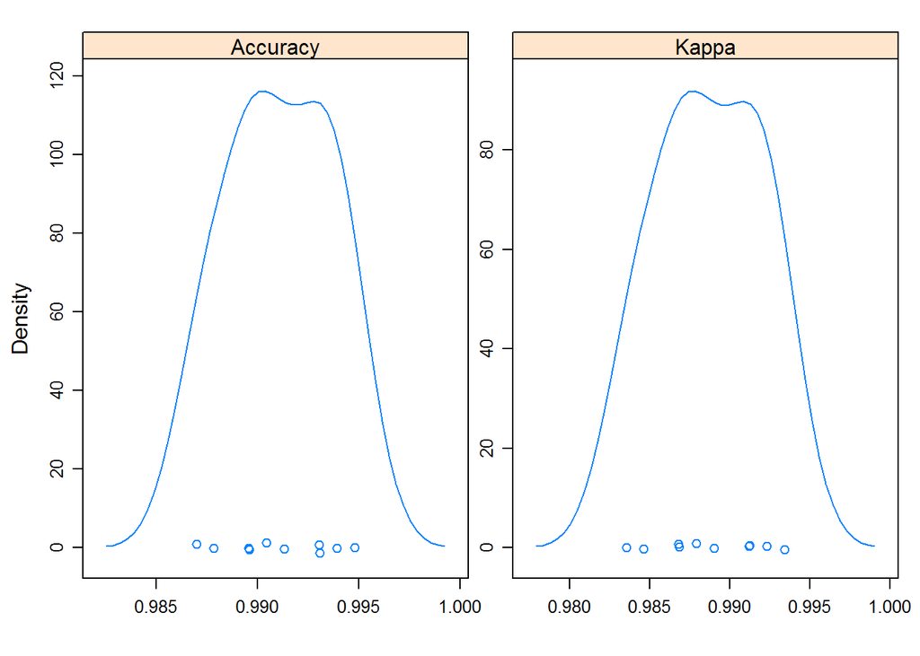

```r
resampleHist(fitRF)
```

The 30 most important variables are shown here:

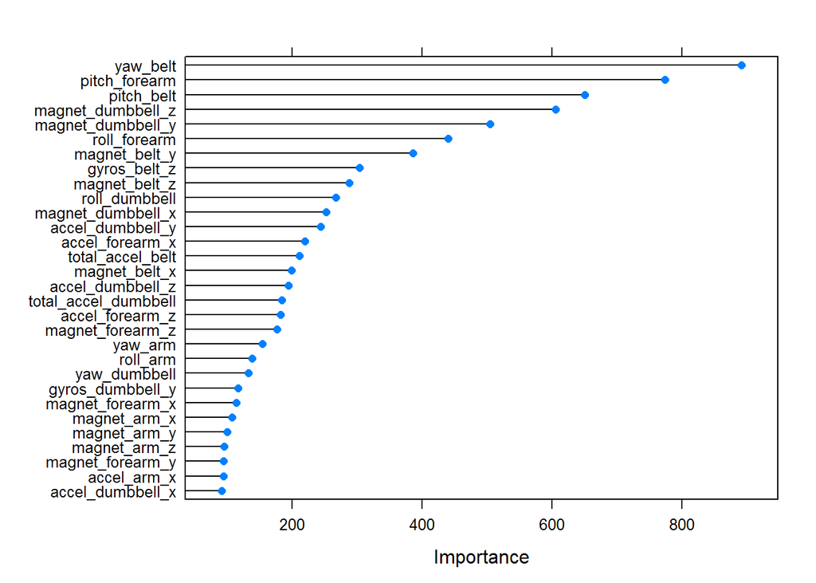

```r
plot(varImp(fitRF, scale=FALSE), top=30)
```

#### Final Prediction

We make the final prediction using the test data set:

```r
predTest <- predict(fitRF, processedTest)
```

The results of the prediction are:

```r
##  1  2  3  4  5  6  7  8  9 10 11 12 13 14 15 16 17 18 19 20
##  B  A  B  A  A  E  D  B  A  A  B  C  B  A  E  E  A  B  B  B
```